# 1.Import the dataset

```python
# Importing all the necessary libraries
import pandas as pd
import numpy as np
import warnings
# Warning handling
from pandas.errors import DtypeWarning
warnings.filterwarnings("ignore", category=DtypeWarning)
# Reading csv file and loading data into the dataframe
df = pd.read_csv("Customer Service_Requests_from_2010_to_Present.csv")
#printing the dataframe
df
```

|  | Unique Key | Created Date | Closed Date | Agency | Agency Name | Complaint Type | Descriptor | Location Type | Incident Zip | Incident Address | Street Name | Cross Street 1 | Cross Street 2 | Intersection Street 1 | Intersection Street 2 | Address Type | City | Landmark | Facility Type | Status | Due Date | Resolution Description | Resolution Action Updated Date | Community Board | Borough | X Coordinate (State Plane) | Y Coordinate (State Plane) | Park Facility Name | Park Borough | … |
| --- | --- | --- | --- | --- | --- | --- | --- | --- | --- | --- | --- | --- | --- | --- | --- | --- | --- | --- | --- | --- | --- | --- | --- | --- | --- | --- | --- | --- | --- | --- |
| 0 | 32310363 | 12/31/2015 11:59:45 PM | 01-01-16 0:55 | NYPD | New York City Police Department | Noise - Street/Sidewalk | Loud Music/Party | Street/Sidewalk | 10034.0 | 71 VERMILYEA AVENUE | VERMILYEA AVENUE | ACADEMY STREET | WEST 204 STREET | NaN | NaN | ADDRESS | NEW YORK | NaN | Precinct | Closed | 01-01-16 7:59 | The Police Department responded and upon arriv... | 01-01-16 0:55 | 12 MANHATTAN | MANHATTAN | 1005409.0 | 254678.0 | Unspecified | MANHATTAN | … |
| 1 | 32309934 | 12/31/2015 11:59:44 PM | 01-01-16 1:26 | NYPD | New York City Police Department | Blocked Driveway | No Access | Street/Sidewalk | 11105.0 | 27-07 23 AVENUE | 23 AVENUE | 27 STREET | 28 STREET | NaN | NaN | ADDRESS | ASTORIA | NaN | Precinct | Closed | 01-01-16 7:59 | The Police Department responded to the complai... | 01-01-16 1:26 | 01 QUEENS | QUEENS | 1007766.0 | 221986.0 | Unspecified | QUEENS | … |
| 2 | 32309159 | 12/31/2015 11:59:29 PM | 01-01-16 4:51 | NYPD | New York City Police Department | Blocked Driveway | No Access | Street/Sidewalk | 10458.0 | 2897 VALENTINE AVENUE | VALENTINE AVENUE | EAST 198 STREET | EAST 199 STREET | NaN | NaN | ADDRESS | BRONX | NaN | Precinct | Closed | 01-01-16 7:59 | The Police Department responded and upon arriv... | 01-01-16 4:51 | 07 BRONX | BRONX | 1015081.0 | 256380.0 | Unspecified | BRONX | … |
| 3 | 32305098 | 12/31/2015 11:57:46 PM | 01-01-16 7:43 | NYPD | New York City Police Department | Illegal Parking | Commercial Overnight Parking | Street/Sidewalk | 10461.0 | 2940 BAISLEY AVENUE | BAISLEY AVENUE | EDISON AVENUE | B STREET | NaN | NaN | ADDRESS | BRONX | NaN | Precinct | Closed | 01-01-16 7:57 | The Police Department responded to the complai... | 01-01-16 7:43 | 10 BRONX | BRONX | 1031740.0 | 243899.0 | Unspecified | BRONX | … |
| 4 | 32306529 | 12/31/2015 11:56:58 PM | 01-01-16 3:24 | NYPD | New York City Police Department | Illegal Parking | Blocked Sidewalk | Street/Sidewalk | 11373.0 | 87-14 57 ROAD | 57 ROAD | SEABURY STREET | HOFFMAN DRIVE | NaN | NaN | ADDRESS | ELMHURST | NaN | Precinct | Closed | 01-01-16 7:56 | The Police Department responded and upon arriv... | 01-01-16 3:24 | 04 QUEENS | QUEENS | 1019123.0 | 206375.0 | Unspecified | QUEENS | … |
| ... | ... | ... | ... | ... | ... | ... | ... | ... | ... | ... | ... | ... | ... | ... | ... | ... | ... | ... | ... | ... | ... | ... | ... | ... | ... | ... | ... | ... | ... | … |
| 300693 | 30281872 | 03/29/2015 12:33:41 AM | NaN | NYPD | New York City Police Department | Noise - Commercial | Loud Music/Party | Club/Bar/Restaurant | NaN | CRESCENT AVENUE | CRESCENT AVENUE | EAST 186 | NaN | east 186 | NaN | NaN | NaN | NaN | NaN | Open | 03/29/2015 08:33:41 AM | Your complaint has been forwarded to the New Y... | NaN | 0 Unspecified | Unspecified | NaN | NaN | Unspecified | Unspecified | … |
| 300694 | 30281230 | 03/29/2015 12:33:28 AM | 03/29/2015 02:33:59 AM | NYPD | New York City Police Department | Blocked Driveway | Partial Access | Street/Sidewalk | 11418.0 | 100-17 87 AVENUE | 87 AVENUE | DEAD END | 102 STREET | NaN | NaN | ADDRESS | RICHMOND HILL | NaN | Precinct | Closed | 03/29/2015 08:33:28 AM | The Police Department responded and upon arriv... | 03/29/2015 02:33:59 AM | 09 QUEENS | QUEENS | 1026931.0 | 192185.0 | Unspecified | QUEENS | … |
| 300695 | 30283424 | 03/29/2015 12:33:03 AM | 03/29/2015 03:40:20 AM | NYPD | New York City Police Department | Noise - Commercial | Loud Music/Party | Club/Bar/Restaurant | 11206.0 | 162 THROOP AVENUE | THROOP AVENUE | HOPKINS STREET | ELLERY STREET | NaN | NaN | ADDRESS | BROOKLYN | NaN | Precinct | Closed | 03/29/2015 08:33:03 AM | The Police Department responded to the complai... | 03/29/2015 03:40:20 AM | 03 BROOKLYN | BROOKLYN | 999713.0 | 194161.0 | Unspecified | BROOKLYN | … |
| 300696 | 30280004 | 03/29/2015 12:33:02 AM | 03/29/2015 04:38:35 AM | NYPD | New York City Police Department | Noise - Commercial | Loud Music/Party | Club/Bar/Restaurant | 10461.0 | 3151 EAST TREMONT AVENUE | EAST TREMONT AVENUE | CODDINGTON AVENUE | LA SALLE AVENUE | NaN | NaN | ADDRESS | BRONX | NaN | Precinct | Closed | 03/29/2015 08:33:02 AM | The Police Department responded to the complai... | 03/29/2015 04:38:35 AM | 10 BRONX | BRONX | 1030021.0 | 244520.0 | Unspecified | BRONX | … |
| 300697 | 30281825 | 03/29/2015 12:33:01 AM | 03/29/2015 04:41:50 AM | NYPD | New York City Police Department | Noise - Commercial | Loud Music/Party | Store/Commercial | 10036.0 | 251 WEST 48 STREET | WEST 48 STREET | BROADWAY | 8 AVENUE | NaN | NaN | ADDRESS | NEW YORK | NaN | Precinct | Closed | 03/29/2015 08:33:01 AM | The Police Department responded to the complai... | 03/29/2015 04:41:50 AM | 05 MANHATTAN | MANHATTAN | 988150.0 | 216378.0 | Unspecified | MANHATTAN | … |

300698 rows × 53 columns

# 2. Provide your insight on the information and details that the provided dataset carries

# 2.1 Displaying columns present in the dataset

```python
# Making a dataframe that will only contain the columns from the original dataframe
df2 = pd.DataFrame({" ": df.columns})
# Printing the dataframe and formatting the output
print("—"*36)
print("S.no\t\t\tColumn Name")
print("—"*36)
print(df2)
print("_"*36)
```

```
————————————————————————————————————
S.no			Column Name
————————————————————————————————————

0                       Unique Key
1                     Created Date
2                      Closed Date
3                           Agency
4                      Agency Name
5                   Complaint Type
6                       Descriptor
7                    Location Type
8                     Incident Zip
9                 Incident Address
10                     Street Name
```

[output cut: 43 more lines]

# 2.2 Column Insight

```python
# Printing the dataframe info as summary
print("—"*42)
print("DATASET SUMMARY: Customer Service Requests");
print("—"*42)
print(df.info());
```

```
——————————————————————————————————————————
DATASET SUMMARY: Customer Service Requests
——————————————————————————————————————————
<class 'pandas.core.frame.DataFrame'>
RangeIndex: 300698 entries, 0 to 300697
Data columns (total 53 columns):
 #   Column                          Non-Null Count   Dtype
---  ------                          --------------   -----
 0   Unique Key                      300698 non-null  int64
 1   Created Date                    300698 non-null  object
 2   Closed Date                     298534 non-null  object
 3   Agency                          300698 non-null  object
 4   Agency Name                     300698 non-null  object
 5   Complaint Type                  300698 non-null  object
 6   Descriptor                      294784 non-null  object
```

[output cut: 49 more lines]

# 2.3 Columns and the number of unique values they contain

```python
print("—"*75)
print("The columns with their respective number of unique values are listed below:")
print("—"*75 + "\n")
print("—"*55)
print("Columns\t\t\t\tNumber of unique values")
print("—"*55)
# Printing the columns and their unique value count
print(df.nunique())
```

```
———————————————————————————————————————————————————————————————————————————
The columns with their respective number of unique values are listed below:
———————————————————————————————————————————————————————————————————————————

———————————————————————————————————————————————————————
Columns				Number of unique values
———————————————————————————————————————————————————————
Unique Key                        300698
Created Date                      259493
Closed Date                       237165
Agency                                 1
Agency Name                            3
Complaint Type                        24
Descriptor                            45
Location Type                         18
Incident Zip                         201
Incident Address                  107652
Street Name                         7320
Cross Street 1                      5982
Cross Street 2                      5823
Intersection Street 1               4413
Intersection Street 2               4172
Address Type                           5
City                                  53
Landmark                             116
Facility Type                          1
Status                                 4
Due Date                          259851
Resolution Description                18
Resolution Action Updated Date    237895
Community Board                       75
Borough                                6
X Coordinate (State Plane)         63226
Y Coordinate (State Plane)         73694
Park Facility Name                     2
Park Borough                           6
School Name                            2
School Number                          2
School Region                          1
School Code                            1
School Phone Number                    2
School Address                         2
School City                            2
School State                           2
School Zip                             1
School Not Found                       1
School or Citywide Complaint           0
Vehicle Type                           0
Taxi Company Borough                   0
Taxi Pick Up Location                  0
Bridge Highway Name                   29
Bridge Highway Direction              34
Road Ramp                              2
Bridge Highway Segment               160
Garage Lot Name                        0
Ferry Direction                        1
Ferry Terminal Name                    2
Latitude                          125122
Longitude                         125216
Location                          126048
dtype: int64
```

# 3. Convert the columns "Created Date" and "Closed Date" to datetime datatype and create a new column "Request_Closing_Time" as the time elapsed between request creation and request closing.

```python
#Converting the columns "Created Date" and "Closed Date" to datetime datatype
df['Created Date']=pd.to_datetime(df['Created Date'])
df['Closed Date']=pd.to_datetime(df['Closed Date'])

#Creating a new column "Request_Closing_Time" which is the time elapsed between request creation and request closing
df['Request_Closing_Time']= df['Closed Date'] - df['Created Date']

# Displaying 10 sample outputs of the above 3 columns
display = df[['Created Date', 'Closed Date', 'Request_Closing_Time']].head(10).to_string(index=False)
print("Created Date \t\tClosed Date \t\tRequest Closing Time")
for i in range(10):
    print(f"{df['Created Date'].iloc[i]}  |  {df['Closed Date'].iloc[i]}  |  {df['Request_Closing_Time'].iloc[i]}")
```

```
Created Date 		Closed Date 		Request Closing Time
2015-12-31 23:59:45  |  2016-01-01 00:55:00  |  0 days 00:55:15
2015-12-31 23:59:44  |  2016-01-01 01:26:00  |  0 days 01:26:16
2015-12-31 23:59:29  |  2016-01-01 04:51:00  |  0 days 04:51:31
2015-12-31 23:57:46  |  2016-01-01 07:43:00  |  0 days 07:45:14
2015-12-31 23:56:58  |  2016-01-01 03:24:00  |  0 days 03:27:02
2015-12-31 23:56:30  |  2016-01-01 01:50:00  |  0 days 01:53:30
2015-12-31 23:55:32  |  2016-01-01 01:53:00  |  0 days 01:57:28
2015-12-31 23:54:05  |  2016-01-01 01:42:00  |  0 days 01:47:55
2015-12-31 23:53:58  |  2016-01-01 08:27:00  |  0 days 08:33:02
2015-12-31 23:53:58  |  2016-01-01 01:17:00  |  0 days 01:23:02
```

# 4. Write a python program to drop irrelevant Columns.

```python
df3 = df.drop(columns=['Agency Name', 'Incident Address', 'Street Name', 'Cross Street 1', 'Cross Street 2',
    'Intersection Street 1', 'Intersection Street 2', 'Address Type', 'Park Facility Name',
    'Park Borough', 'School Name', 'School Number', 'School Region', 'School Code',
    'School Phone Number', 'School Address', 'School City', 'School State', 'School Zip',
    'School Not Found', 'School or Citywide Complaint', 'Vehicle Type', 'Taxi Company Borough',
    'Taxi Pick Up Location', 'Bridge Highway Name', 'Bridge Highway Direction', 'Road Ramp',
    'Bridge Highway Segment', 'Garage Lot Name', 'Ferry Direction', 'Ferry Terminal Name',
    'Landmark', 'X Coordinate (State Plane)', 'Y Coordinate (State Plane)', 'Due Date',
    'Resolution Action Updated Date', 'Community Board', 'Facility Type', 'Location'])
display = pd.DataFrame({" ": df3.columns})
display
```

| 0 | Unique Key |
| --- | --- |
| 1 | Created Date |
| 2 | Closed Date |
| 3 | Agency |
| 4 | Complaint Type |
| 5 | Descriptor |
| 6 | Location Type |
| 7 | Incident Zip |
| 8 | City |
| 9 | Status |
| 10 | Resolution Description |
| 11 | Borough |
| 12 | Latitude |
| 13 | Longitude |
| 14 | Request_Closing_Time |

# 5. Write a python program to remove the NaN missing values from updated dataframe.

```python
#Chceking for the presence of missing values in dataframe
df3.isna()
```

|  | Unique Key | Created Date | Closed Date | Agency | Complaint Type | Descriptor | Location Type | Incident Zip | City | Status | Resolution Description | Borough | Latitude | Longitude | Request_Closing_Time |
| --- | --- | --- | --- | --- | --- | --- | --- | --- | --- | --- | --- | --- | --- | --- | --- |
| 0 | False | False | False | False | False | False | False | False | False | False | False | False | False | False | False |
| 1 | False | False | False | False | False | False | False | False | False | False | False | False | False | False | False |
| 2 | False | False | False | False | False | False | False | False | False | False | False | False | False | False | False |
| 3 | False | False | False | False | False | False | False | False | False | False | False | False | False | False | False |
| 4 | False | False | False | False | False | False | False | False | False | False | False | False | False | False | False |
| ... | ... | ... | ... | ... | ... | ... | ... | ... | ... | ... | ... | ... | ... | ... | ... |
| 300693 | False | False | True | False | False | False | False | True | True | False | False | False | True | True | True |
| 300694 | False | False | False | False | False | False | False | False | False | False | False | False | False | False | False |
| 300695 | False | False | False | False | False | False | False | False | False | False | False | False | False | False | False |
| 300696 | False | False | False | False | False | False | False | False | False | False | False | False | False | False | False |
| 300697 | False | False | False | False | False | False | False | False | False | False | False | False | False | False | False |

300698 rows × 15 columns

```python
# Dropping the NaN missing values from the dataframe
df4 = df3.dropna()
# Again recheking if theres any missing values present in the dataframe
df4.isna()
```

|  | Unique Key | Created Date | Closed Date | Agency | Complaint Type | Descriptor | Location Type | Incident Zip | City | Status | Resolution Description | Borough | Latitude | Longitude | Request_Closing_Time |
| --- | --- | --- | --- | --- | --- | --- | --- | --- | --- | --- | --- | --- | --- | --- | --- |
| 0 | False | False | False | False | False | False | False | False | False | False | False | False | False | False | False |
| 1 | False | False | False | False | False | False | False | False | False | False | False | False | False | False | False |
| 2 | False | False | False | False | False | False | False | False | False | False | False | False | False | False | False |
| 3 | False | False | False | False | False | False | False | False | False | False | False | False | False | False | False |
| 4 | False | False | False | False | False | False | False | False | False | False | False | False | False | False | False |
| ... | ... | ... | ... | ... | ... | ... | ... | ... | ... | ... | ... | ... | ... | ... | ... |
| 300692 | False | False | False | False | False | False | False | False | False | False | False | False | False | False | False |
| 300694 | False | False | False | False | False | False | False | False | False | False | False | False | False | False | False |
| 300695 | False | False | False | False | False | False | False | False | False | False | False | False | False | False | False |
| 300696 | False | False | False | False | False | False | False | False | False | False | False | False | False | False | False |
| 300697 | False | False | False | False | False | False | False | False | False | False | False | False | False | False | False |

291107 rows × 15 columns

# 6. Write a python program to see the unique values from all the columns in the dataframe.

```python
print("\t\t\t\t\t"+ "-"*60)
print("\t\t\t\t\tThe columns along with their unique values are listed below:")
print("\t\t\t\t\t"+ "-"*60 + "\n")
# Displaying the column names along with their unique value count and a list of unique values
for col in df4.columns:
    unique_vals = df4[col].unique()
    print(f"-" * 25)
    print(f"  Column: {col}")
    print(f"-" * 25)
    print(f"  Number of Unique Values: {len(unique_vals)}")
    print(f"  Unique Values: {unique_vals}\n")
    print(f"—" * 150 +"\n")
```

```
					------------------------------------------------------------
					The columns along with their unique values are listed below:
					------------------------------------------------------------

-------------------------
  Column: Unique Key
-------------------------
  Number of Unique Values: 291107
  Unique Values: [32310363 32309934 32309159 ... 30283424 30280004 30281825]

——————————————————————————————————————————————————————————————————————————————————————————————————————————————————————————————————————————————————————

-------------------------
  Column: Created Date
-------------------------
  Number of Unique Values: 251970
  Unique Values: <DatetimeArray>
['2015-12-31 23:59:45', '2015-12-31 23:59:44', '2015-12-31 23:59:29', '2015-12-31 23:57:46', '2015-12-31 23:56:58', '2015-12-31 23:56:30', '2015-12-31 23:55:32', '2015-12-31 23:54:05', '2015-12-31 23:53:58', '2015-12-31 23:52:58',
 ...
 '2015-03-29 00:42:48', '2015-03-29 00:37:15', '2015-03-29 00:35:28', '2015-03-29 00:35:23', '2015-03-29 00:35:04', '2015-03-29 00:34:32', '2015-03-29 00:33:28', '2015-03-29 00:33:03', '2015-03-29 00:33:02', '2015-03-29 00:33:01']
Length: 251970, dtype: datetime64[ns]

——————————————————————————————————————————————————————————————————————————————————————————————————————————————————————————————————————————————————————

-------------------------
  Column: Closed Date
-------------------------
  Number of Unique Values: 231991
  Unique Values: <DatetimeArray>
['2016-01-01 00:55:00', '2016-01-01 01:26:00', '2016-01-01 04:51:00', '2016-01-01 07:43:00', '2016-01-01 03:24:00', '2016-01-01 01:50:00', '2016-01-01 01:53:00', '2016-01-01 01:42:00', '2016-01-01 08:27:00', '2016-01-01 01:17:00',
 ...
 '2015-03-29 00:57:23', '2015-03-29 02:57:41', '2015-03-29 01:02:39', '2015-03-29 04:14:27', '2015-03-29 08:41:24', '2015-03-29 02:52:28', '2015-03-29 01:13:01', '2015-03-29 02:33:59', '2015-03-29 04:38:35', '2015-03-29 04:41:50']
Length: 231991, dtype: datetime64[ns]

——————————————————————————————————————————————————————————————————————————————————————————————————————————————————————————————————————————————————————

-------------------------
  Column: Agency
-------------------------
  Number of Unique Values: 1
```

[output cut: 140 more lines]

```
 -73.9913785 ]

——————————————————————————————————————————————————————————————————————————————————————————————————————————————————————————————————————————————————————

-------------------------
  Column: Request_Closing_Time
-------------------------
  Number of Unique Values: 47134
  Unique Values: <TimedeltaArray>
['0 days 00:55:15', '0 days 01:26:16', '0 days 04:51:31', '0 days 07:45:14', '0 days 03:27:02', '0 days 01:53:30', '0 days 01:57:28', '0 days 01:47:55', '0 days 08:33:02', '0 days 01:23:02',
 ...
 '0 days 06:46:59', '0 days 07:28:23', '0 days 05:13:46', '0 days 05:19:11', '0 days 10:22:47', '0 days 09:46:41', '0 days 15:40:46', '0 days 04:44:52', '0 days 09:44:44', '0 days 15:42:26']
Length: 47134, dtype: timedelta64[ns]

——————————————————————————————————————————————————————————————————————————————————————————————————————————————————————————————————————————————————————
```

# 1. Write a Python program to show summary statistics of sum, mean, standard deviation, skewness, and kurtosis of the data frame.

```python
# Selecting only numerical columns from the dataframe and storing into a new dataframe named df5
df5 = df4.select_dtypes(include=[np.number])
# dropping the unique key and date time columns from df5
df5 = df5.drop(columns=['Unique Key'])
df5 = df5.drop(columns=['Request_Closing_Time'])
# Displaying all the statistical measures for df5
df5.describe()
```

|  | Incident Zip | Latitude | Longitude |
| --- | --- | --- | --- |
| count | 291107.000000 | 291107.000000 | 291107.000000 |
| mean | 10857.977349 | 40.725681 | -73.925035 |
| std | 580.280774 | 0.082411 | 0.078654 |
| min | 83.000000 | 40.499135 | -74.254937 |
| 25% | 10314.000000 | 40.668926 | -73.970957 |
| 50% | 11209.000000 | 40.717782 | -73.930774 |
| 75% | 11238.000000 | 40.782973 | -73.875788 |
| max | 11697.000000 | 40.912869 | -73.700760 |

```python
# making a dataframe that will only contain sum, mean, standard deviation, skewness and kurtosis
summary_stats = pd.DataFrame({
    'Sum': df5.sum(),
    'Mean': df5.mean(),
    'Standard Deviation': df5.std(),
    'Skewness': df5.skew(),
    'Kurtosis': df5.kurt()
})
# Round for cleaner display
summary_stats = summary_stats.round(2)

# Displaying results
print("\t\t\t\t"+"—" * 20)
print("\t\t\t\t Summary Statistics ")
print("\t\t\t\t"+"—" * 20 + "\n")
print(summary_stats)
```

```
				————————————————————
				 Summary Statistics
				————————————————————

                       Sum      Mean  Standard Deviation  Skewness  Kurtosis
Incident Zip  3.160833e+09  10857.98              580.28     -2.55     37.83
Latitude      1.185553e+07     40.73                0.08      0.12     -0.73
Longitude    -2.152010e+07    -73.93                0.08     -0.31      1.46
```

# 2. Write a Python program to calculate and show correlation of all variables.

```python
print("\t\t"+"—" * 13)
print("\t\t Correlation ")
print("\t\t"+"—" * 13 + "\n")
# Displaying the correlation between all the relevant numerical variables
df5.corr()
```

```
		—————————————
		 Correlation
		—————————————
```

|  | Incident Zip | Latitude | Longitude |
| --- | --- | --- | --- |
| Incident Zip | 1.000000 | -0.499081 | 0.385934 |
| Latitude | -0.499081 | 1.000000 | 0.368819 |
| Longitude | 0.385934 | 0.368819 | 1.000000 |

# Data Exploration

## 1. Provide four major insights through visualization that you come up after data mining

#### Insight 1: Identifying the top 10 most common complaint types

```python
import matplotlib.pyplot as plt
```

```python
# Calculating the number of complaints for each complaint type
Number_of_complaints = df4['Complaint Type'].value_counts()
# Selecting only top 10 complaint types based on their count
Top_10_complaints = Number_of_complaints.head(10)
print("—" * 25)
print("Top 10 complaint types ")
print("—" * 25 + "\n")
# Displaying the top 10 complaint types and their count
Top_10_complaints
```

```
—————————————————————————
Top 10 complaint types
—————————————————————————
```

```
Complaint Type
Blocked Driveway           76676
Illegal Parking            74021
Noise - Street/Sidewalk    47747
Noise - Commercial         35144
Derelict Vehicle           17506
Noise - Vehicle            16868
Animal Abuse                7744
Traffic                     4466
Noise - Park                3927
Vending                     3773
Name: count, dtype: int64
```

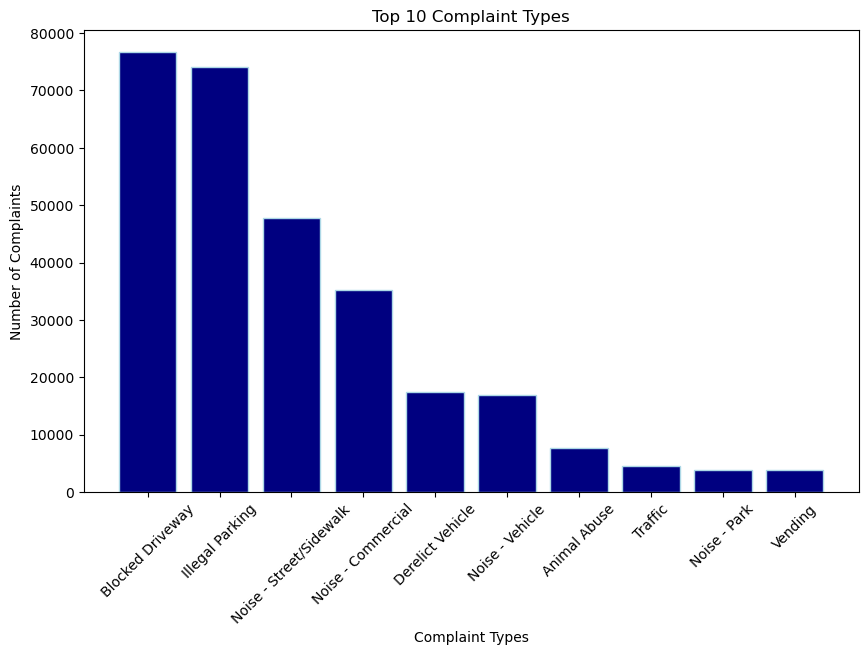

```python
# Visualizing top 10 most common complaint types
plt.figure(figsize=(10, 6))
# Creating a bar graph with x-axis representing complaint types and y-axis representing their count
plt.bar(Top_10_complaints.index, Top_10_complaints.values, color='navy',ec='lightblue')
plt.title('Top 10 Complaint Types')
#putting labels on x-axis and y-axis
plt.ylabel('Number of Complaints')
plt.xlabel('Complaint Types')
plt.xticks(rotation=45);
```

#### Insight 2: Distribution pattern based on borough

```
—————————————————————————
 Distribution by borough
—————————————————————————

Borough
BROOKLYN         96858
QUEENS           79790
MANHATTAN        62033
BRONX            40217
STATEN ISLAND    12209
Name: count, dtype: int64
```

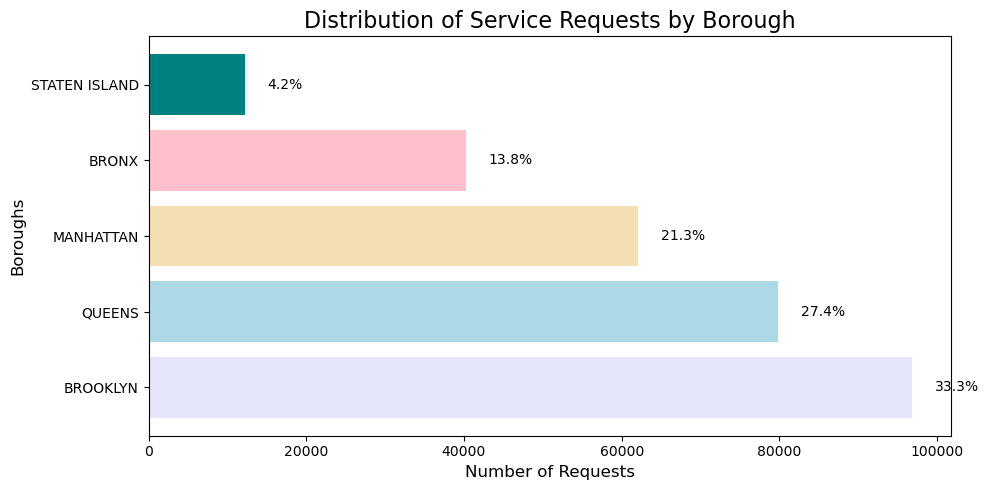

```python
# Counting number of complaints by borough
borough_counts = df4['Borough'].value_counts()
print("—" * 25)
print(" Distribution by borough ")
print("—" * 25 + "\n")
# Displaying the number of complaints by borough
print(borough_counts)
#Visualization
plt.figure(figsize=(10, 5))
#Creating a horizontal bar chart that contains borough as y-axis and its complaint count as x-axis
bars = plt.barh(borough_counts.index, borough_counts.values, color=['lavender', 'lightblue', 'wheat', 'pink', 'teal'])
# Adding percentage labels to each bar
total = borough_counts.sum()
for i, (index, value) in enumerate(borough_counts.items()):
    percentage = 100 * value / total
    plt.text(value + (total * 0.01), i, f'{percentage:.1f}%', va='center')
plt.title('Distribution of Service Requests by Borough', fontsize=16)
#putting labels on x-axis and y-axis
plt.xlabel('Number of Requests', fontsize=12)
plt.ylabel('Boroughs', fontsize=12)
plt.tight_layout()
```

#### Insight 3: Monthly service request trend

```
————————————————————————————————
MONTHLY SERVICE REQUEST ANALYSIS
————————————————————————————————
Total service requests: 291,107
Average monthly requests: 24,259
————————————————————————————————
Monthly request counts:
Jan: 0 requests
Feb: 0 requests
Mar: 2,411 requests
Apr: 26,638 requests
May: 35,220 requests
Jun: 34,289 requests
Jul: 33,231 requests
Aug: 33,663 requests
Sep: 34,149 requests
Oct: 31,689 requests
Nov: 30,009 requests
Dec: 29,808 requests
```

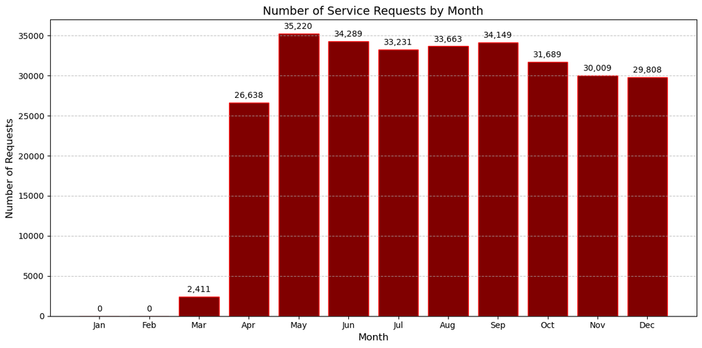

```python
#copying the df4 into another dataframe for analysis
df_analysis = df4.copy()
#Extracting the months from all the created dates and storing them into Month column in dataframe
df_analysis['Month'] = df_analysis['Created Date'].dt.month
# Counting the number of complaints for each month
monthly_counts = df_analysis.groupby('Month').size()
# Making sure that all the months are included
all_months = pd.Series(np.zeros(12), index=range(1, 13))
monthly_counts = monthly_counts.reindex(all_months.index, fill_value=0)
# Statistical measures for the monthly complaint count
total_requests = monthly_counts.sum()
avg_monthly = monthly_counts.mean()


print("—" * 32)
print("MONTHLY SERVICE REQUEST ANALYSIS")
print("—" * 32)
#Displaying total complaint count for that year
print(f"Total service requests: {total_requests:,.0f}")
#Displaying average monthly complaint count for that year
print(f"Average monthly requests: {avg_monthly:,.0f}")
print("—" * 32)
print("Monthly request counts:")
#Displaying monthly complaint count for each month of the year
for i, month in enumerate(months):
    count = monthly_counts[i+1]
    print(f"{month}: {count:,.0f} requests")

# Visualization
plt.figure(figsize=(12, 6))
#making bar chart that contains months in x-axis and their respective complaint counts in y-axis
bars = plt.bar(monthly_counts.index, monthly_counts.values, color='maroon', ec="red")
plt.title('Number of Service Requests by Month', fontsize=14)
#Adding labels in y-axis and x-axis
plt.xlabel('Month', fontsize=12)
plt.ylabel('Number of Requests', fontsize=12)
months = ['Jan', 'Feb', 'Mar', 'Apr', 'May', 'Jun', 'Jul', 'Aug', 'Sep', 'Oct', 'Nov', 'Dec']
plt.xticks(ticks=range(1, 13), labels=months)
plt.grid(axis='y', linestyle='--', alpha=0.7)
#Adding count value on top of eacg bar
if monthly_counts.max() > 0:
    for bar in bars:
        height = bar.get_height()
        plt.text(bar.get_x() + bar.get_width()/2., height + 0.01*monthly_counts.max(),
                f'{height:,.0f}', ha='center', va='bottom')
plt.tight_layout()
plt.show()
```

#### Insight 4: Response time analysis

```
---------------------------------------------
NYPD Average Response Time Analysis by Borough:
---------------------------------------------
MANHATTAN: 2.94 hours
STATEN ISLAND: 3.87 hours
BROOKLYN: 4.04 hours
QUEENS: 4.87 hours
BRONX: 6.09 hours
---------------------------------------------
Fastest response: MANHATTAN (2.94 hours)
Slowest response: BRONX (6.09 hours)
Overall average response time: 4.31 hours
```

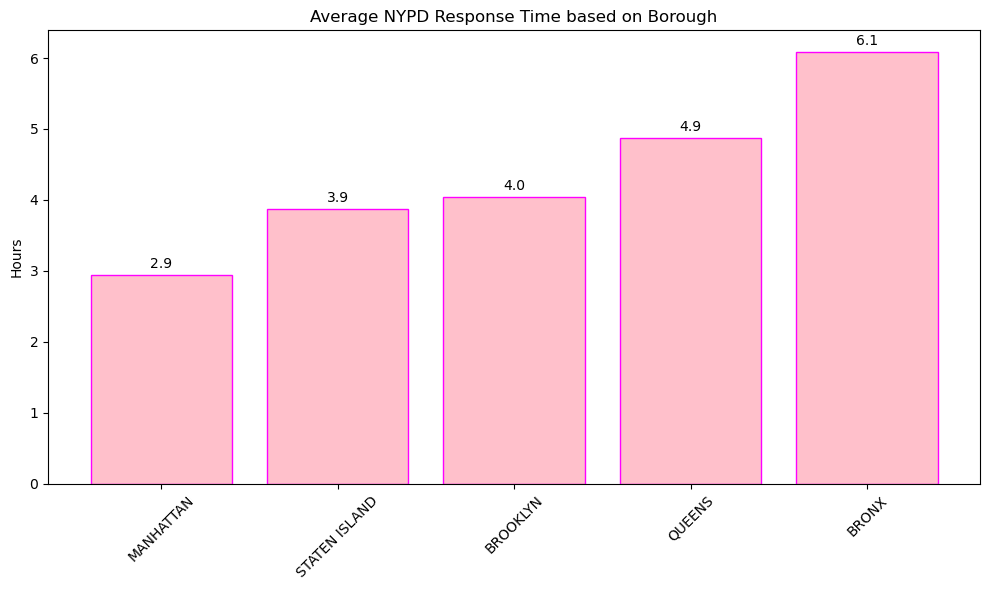

```python
#Calculating response hours from closing time
df4.loc[:, 'Response_Hours'] = df4['Request_Closing_Time'].dt.total_seconds() / 3600
warnings.filterwarnings("ignore", category=DtypeWarning)
# Calculating average response hours per borough
borough_average_response_time = df4.groupby('Borough')['Response_Hours'].mean().sort_values()
print("-" * 45)
print("NYPD Average Response Time Analysis by Borough:")
print("-" * 45)
#printing the average response hours for each borough
for borough, hours in borough_average_response_time.items():
    print(f"{borough}: {hours:.2f} hours")
print("-" * 45)
#printing the overall fastest, slowest and average response tine
print(f"Fastest response: {borough_average_response_time.index[0]} ({borough_average_response_time.values[0]:.2f} hours)")
print(f"Slowest response: {borough_average_response_time.index[-1]} ({borough_average_response_time.values[-1]:.2f} hours)")
print(f"Overall average response time: {df4['Response_Hours'].mean():.2f} hours")

# Creating the bar chart with borough as x-axis and hours as y-axis
plt.figure(figsize=(10, 6))
plt.bar(borough_average_response_time.index, borough_average_response_time.values, color='pink', ec="magenta")
plt.title('Average NYPD Response Time based on Borough')
plt.ylabel('Hours')
plt.xticks(rotation=45)
# Adding value labels on the top of each bar
for i, v in enumerate(borough_average_response_time.values):
    plt.text(i, v + 0.1, f"{v:.1f}", ha='center')
plt.tight_layout()
plt.show()
```

## 2. Arrange the complaint types according to their average 'Request_Closing_Time', categorized by various locations. Illustrate it through graph as well.

```
Analysis of Complaint Types by Average Request Closing Time
============================================================

Location: Street/Sidewalk
--------------------------------------------------
  Top 5 Complaint Types by Average Response Time:
  Graffiti: 12.04 hours
  Derelict Vehicle: 7.34 hours
  Animal Abuse: 5.13 hours
  Blocked Driveway: 4.74 hours
  Illegal Parking: 4.48 hours
  Average response time across all complaints at this location: 4.48 hours
__________________________________________________________________________________________________________________________________________________

Location: Store/Commercial
--------------------------------------------------
  Top 5 Complaint Types by Average Response Time:
  Graffiti: 5.56 hours
  Animal Abuse: 4.28 hours
  Vending: 3.97 hours
  Drinking: 3.25 hours
  Noise - Commercial: 3.21 hours
  Average response time across all complaints at this location: 3.26 hours
__________________________________________________________________________________________________________________________________________________

Location: Club/Bar/Restaurant
--------------------------------------------------
  Top 5 Complaint Types by Average Response Time:
  Drinking: 4.55 hours
  Noise - Commercial: 3.06 hours
  Average response time across all complaints at this location: 3.09 hours
__________________________________________________________________________________________________________________________________________________

Location: Residential Building/House
--------------------------------------------------
  Top 5 Complaint Types by Average Response Time:
  Graffiti: 5.88 hours
  Animal Abuse: 5.40 hours
  Vending: 4.20 hours
  Disorderly Youth: 3.85 hours
  Drinking: 3.68 hours
  Average response time across all complaints at this location: 5.24 hours
__________________________________________________________________________________________________________________________________________________

Location: Park/Playground
--------------------------------------------------
  Top 5 Complaint Types by Average Response Time:
  Animal Abuse: 3.67 hours
  Vending: 3.47 hours
  Noise - Park: 3.40 hours
  Drinking: 3.36 hours
  Average response time across all complaints at this location: 3.41 hours
__________________________________________________________________________________________________________________________________________________
```

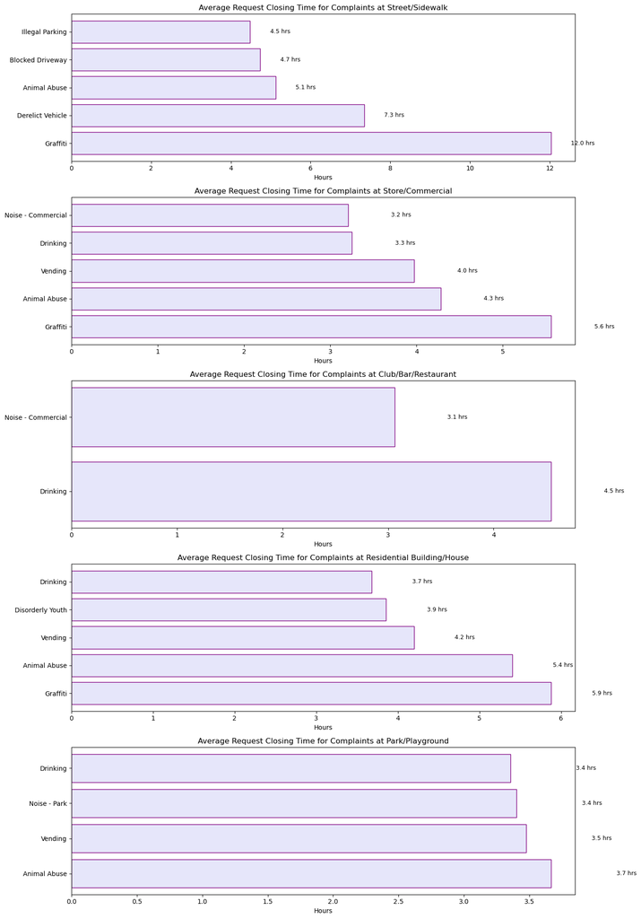

```python
# Get top 5 location types
top_locations = df4['Location Type'].value_counts().head(5).index.tolist()
print("Analysis of Complaint Types by Average Request Closing Time")
print("=" * 60)
# extracting location names and their average response hour grouped by their complaint types
for location in top_locations:
    location_data = df4[df4['Location Type'] == location]
    complaint_times = location_data.groupby('Complaint Type')['Response_Hours'].mean().sort_values(ascending=False).head(5)
    #printing the locations and their average response time based on their top 5 complaint types
    print(f"\nLocation: {location}")
    print("-" * 50)
    print("  Top 5 Complaint Types by Average Response Time:")
    for complaint, hours in complaint_times.items():
        print(f"  {complaint}: {hours:.2f} hours")
    #also printing the average response hours for all complaints in the location
    print(f"  Average response time across all complaints at this location: {location_data['Response_Hours'].mean():.2f} hours")
    print("_" * 146)

#Visualization
# Creating a multi-plot figure with one subplot for each location type
fig, axes = plt.subplots(len(top_locations), 1, figsize=(14, 4*len(top_locations)))
# Iterating through each location in the top_locations list
for i, location in enumerate(top_locations):
   location_data = df4[df4['Location Type'] == location]
   # Calculating mean response time for each complaint type at this location and sorting in descending order and taking top 5 longest response times
   complaint_times = location_data.groupby('Complaint Type')['Response_Hours'].mean().sort_values(ascending=False).head(5)
   ax = axes[i]
   # Create horizontal bar chart for this location of i axes
   bars = ax.barh(range(len(complaint_times)), complaint_times.values, color='lavender', ec='purple')
   # Setting position of y-tick marks to match the number of bars
   ax.set_yticks(range(len(complaint_times)))
   # Labeling the y-axis with complaint type names
   ax.set_yticklabels(complaint_times.index)
   ax.set_title(f'Average Request Closing Time for Complaints at {location}', fontsize=12)
   # Labeling the x-axis as hours
   ax.set_xlabel('Hours', fontsize=10)
   # Add exact value labels to the right of each bar
   for j, v in enumerate(complaint_times.values):
       ax.text(v + 0.5, j, f"{v:.1f} hrs", va='center', fontsize=9)
plt.tight_layout()
plt.show()
```

# Statistical Testing

### Test 1: Whether the average response time across complaint types is similar or not.

##### 1.1) Stating Null Hypothesis

##### Null Hypothesis (H0): The average response time across complaint types is similar.

##### Alternate Hypothesis (H1): At least one complaint type has a different average response time.

##### 1.2) Performing the statistical test

```
------------------------------------------------------------------------------------------------------------------------
Analysis of Average Response Time by Top 5 Complaint Types
------------------------------------------------------------------------------------------------------------------------
Top 5 Complaint Types and their average response time:
Blocked Driveway: 4.74 hours
Illegal Parking: 4.48 hours
Noise - Street/Sidewalk: 3.44 hours
Noise - Commercial: 3.14 hours
Derelict Vehicle: 7.35 hours



------------------------------------------------------------------------------------------------------------------------
Statistical Testing:
------------------------------------------------------------------------------------------------------------------------
ANOVA F-statistic: 1789.81
p-value: 0.0000
________________________________________________________________________________________________________________________
```

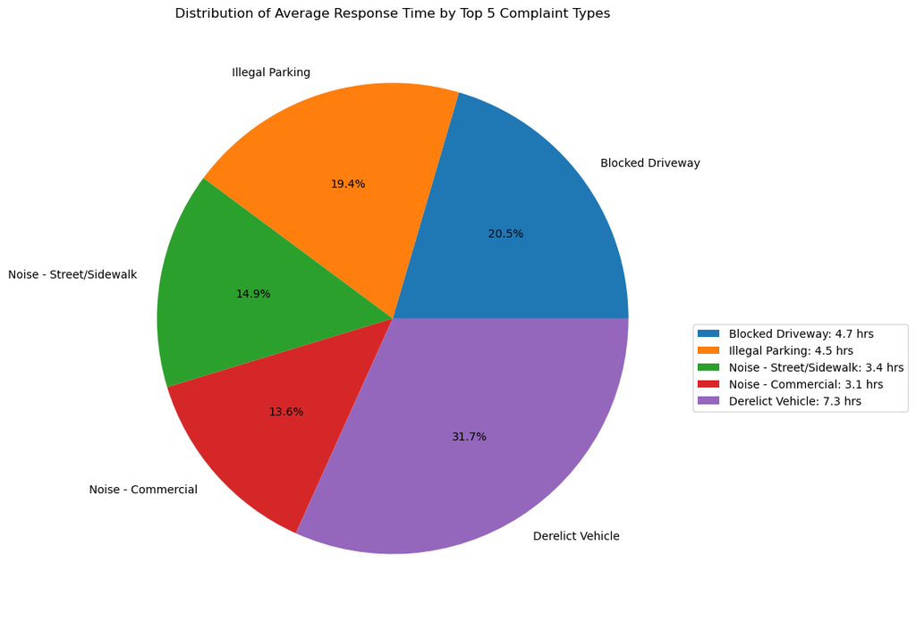

```python
import scipy.stats as stats
# Getting the top 5 most frequent complaint types from the dataset
Top_5_complaints = df4['Complaint Type'].value_counts().head(5).index.tolist()
# Filtering and making a dataframe to include only the top 5 complaint types
filtered_df = df4[df4['Complaint Type'].isin(Top_5_complaints)]
# Initializing empty lists to store response time data for each complaint type
complaint_groups = []
complaint_names = []
for complaint in Top_5_complaints:
   # Extract response hours for the current complaint type of the iteration
   group_data = filtered_df[filtered_df['Complaint Type'] == complaint]['Response_Hours'].values
   # Only include complaint types that have data
   if len(group_data) > 0:
       complaint_groups.append(group_data)  # Add response times array to list
       complaint_names.append(complaint)    # Add complaint name to list
# Calculating the average response time for each complaint type
complaint_averages = [group.mean() for group in complaint_groups]
# Create a pandas Series with complaint types as index and average times as values
complaint_times = pd.Series(complaint_averages, index=complaint_names)
print("-" * 120)
print("Analysis of Average Response Time by Top 5 Complaint Types")
print("-" * 120)
# Printing the average response time for each complaint type
print("Top 5 Complaint Types and their average response time:")
for complaint, avg_time in zip(complaint_names, complaint_averages):
   print(f"{complaint}: {avg_time:.2f} hours")
# Performing one-way ANOVA test to determine if the differences in response times are statistically significant
f_statistic, p_value = stats.f_oneway(*complaint_groups)
print(f"\n\n")
print("-" * 120)
print("Statistical Testing:")
print("-" * 120)
# Print the F-statistic
print(f"ANOVA F-statistic: {f_statistic:.2f}")
# Print the p-value
print(f"p-value: {p_value:.4f}")
print("_" * 120)

# Creating a pie chart visualization to show the proportion of response times for each complaint type
plt.figure(figsize=(10, 8))
# Create pie chart with percentages shown on each slice and labels for complaint type
plt.pie(complaint_times, labels=complaint_times.index, autopct='%1.1f%%')
plt.title('Distribution of Average Response Time by Top 5 Complaint Types')
# Create legend labels at right that include both the complaint type and average hours
legend_labels = [f"{complaint}: {hours:.1f} hrs" for complaint, hours in zip(complaint_times.index, complaint_times.values)]
plt.legend(legend_labels, loc='best', bbox_to_anchor=(1, 0.5))
plt.tight_layout()
plt.show()
```

##### 1.3) Interpreting the results

```python
print(f"F-Statistic: {f_statistic:.4f}")
print("—" * 110)
print(f"P-Value: {p_value:.4f}")
print("—" * 110)

# Interpret the results
if p_value < 0.05:
    conclusion = "The null hypothesis is rejected. There is a significant difference in response times across complaint types."
else:
    conclusion = "The null hypothesis is accepted. There is no significant difference in response times across complaint types."

print(conclusion)
```

```
F-Statistic: 1789.8125
——————————————————————————————————————————————————————————————————————————————————————————————————————————————
P-Value: 0.0000
——————————————————————————————————————————————————————————————————————————————————————————————————————————————
The null hypothesis is rejected. There is a significant difference in response times across complaint types.
```

### Test 2: Whether the type of complaint or service requested and location are related.

##### 2.1) Stating null hypothesis

##### Null Hypothesis (H0): The Complaint type and Location type are independent (no relationship)

##### Alternate Hypothesis (H1): The Complaint type and Location type are dependent (there is a relationship)

##### 2.2) Performing the statistical test

```
--------------------------------------------------------------------------------
Contingency Table
--------------------------------------------------------------------------------
Location Type            Club/Bar/Restaurant  Store/Commercial  Street/Sidewalk
Complaint Type
Blocked Driveway                           0                 0            76676
Derelict Vehicle                           0                 0            17411
Illegal Parking                            0                 0            74021
Noise - Commercial                     16807             18337                0
Noise - Street/Sidewalk                    0                 0            47747



--------------------------------------------------------------------------------
Contingency Table Visualization
--------------------------------------------------------------------------------
```

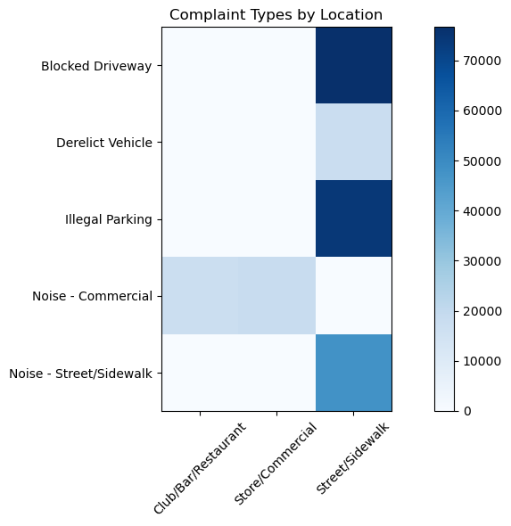

[output not shown]

```python
# Get the top 5 most frequent complaint types from the dataset
Top_5_complaints = df4['Complaint Type'].value_counts().head(5).index.tolist()
Top_5_locations = df4['Location Type'].value_counts().head(5).index.tolist()
# Creating a filtered dataframe that only includes rows where both the complaint type and location type
# are among their respective top 5 most frequent categories
filtered_df = df4[
   df4['Complaint Type'].isin(Top_5_complaints) &
   df4['Location Type'].isin(Top_5_locations)]
# Configure pandas display settings to show all columns
pd.set_option('display.max_columns', None)
# Set display width to avoid wrapping
pd.set_option('display.width', 1000)
# Prevent dataframe from being truncated in display
pd.set_option('display.expand_frame_repr', False)
# Create a contingency table to count the frequency of each complaint type at each location type
contingency_table = pd.crosstab(filtered_df['Complaint Type'], filtered_df['Location Type'])
print("-" * 80)
print("Contingency Table")
print("-" * 80)
print(contingency_table)
print(f"\n\n")
plt.figure(figsize=(10, 6))
# Display the contingency table values as a heatmap using a blue color gradient
plt.imshow(contingency_table.values, cmap='Blues')
print("-" * 80)
print("Contingency Table Visualization")
print("-" * 80)
plt.title('Complaint Types by Location')
# Set x-axis tick labels to the location types
plt.xticks(range(len(contingency_table.columns)), contingency_table.columns, rotation=45)
# Set y-axis tick labels to the complaint types
plt.yticks(range(len(contingency_table.index)), contingency_table.index)
# Adding a color bar legend
plt.colorbar()
plt.tight_layout()
plt.show()

# Perform chi-square test of independence to determine if complaint types are associated with location types
chi2, p_value, dof, expected = stats.chi2_contingency(contingency_table)
print(f"\n\n")
print("-" * 120)
print("Statistical Testing:")
print("-" * 120)
# Print the chi-square statistic
print("_" * 110)
# Print the p-value
print(f"P-Value: {p_value:.4f}")
print("_" * 110)
# Print the degrees of freedom
print(f"Degrees of Freedom: {dof}")
print("_" * 110)
```

##### 2.3) Interpreting the result

```python
print(f"Chi-Square Statistic: {chi2:.4f}")
print("_" * 110)
print(f"P-Value: {p_value:.4f}")
print("_" * 110)
print(f"Degrees of Freedom: {dof}")
print("_" * 110)

# Step 5: Interpret the results
alpha = 0.05
if p_value < alpha:
    conclusion = "The null hypothesis is rejected. There is a significant relationship between complaint type and location."
else:
    conclusion = "The null hypothesis is accepted. There is no significant evidence of a relationship between complaint type and location."
print(conclusion)
```

```
Chi-Square Statistic: 250999.0000
______________________________________________________________________________________________________________
P-Value: 0.0000
______________________________________________________________________________________________________________
Degrees of Freedom: 8
______________________________________________________________________________________________________________
The null hypothesis is rejected. There is a significant relationship between complaint type and location.
```